# FigureYa189timeCindex

**Author(s)**: Xiaofan Lu  
**Reviewer(s)**: Ying Ge, Junyi Shen  
**Date**: 2025-12-27

## 1 Academic Citation

If you use this code in your work or research, we kindly request that you cite our publication:

Xiaofan Lu, et al. (2025). FigureYa: A Standardized Visualization Framework for Enhancing Biomedical Data Interpretation and Research Efficiency. iMetaMed. https://doi.org/10.1002/imm3.70005

## 2 需求描述 Requirement

FigureYa85timeAUC是时间依赖的auc曲线，我想要时间依赖的c-index，没法用之前的包画。

FigureYa85timeAUC is a time-dependent auc curve. I want a time-dependent c-index, which cannot be drawn using the previous package.

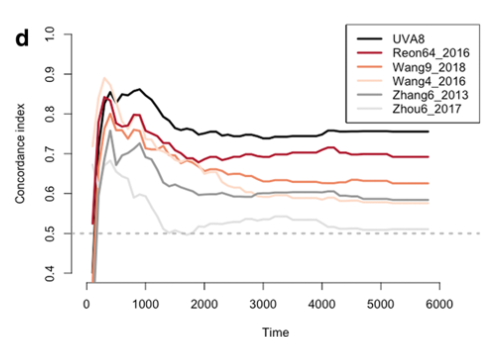

From https://doi.org/10.1007/s12035-018-1416-y

Fig. 5 Performance evaluation of the 8 lncRNA-based risk score. d Concordance index showing measure of concordance of predictor with survival of patients in TCGA

## 3 应用场景 Application Scenarios

时间依赖性C-index，评价不同模型的一致性指数。

Time-dependent C-index, evaluating the consistency index of different models.

## 4 环境设置 Environment Setup

```r
source("install_dependencies.R")
```

```
## Starting R package installation...
## ===========================================
##
## Installing CRAN packages...
## Package already installed: pec
## Package already installed: riskRegression
## Package already installed: survival
##
## ===========================================
## Package installation completed!
## You can now run your R scripts in this directory.
```

```r
library(survival) # 生存分析 Survival analysis
library(pec) # 预测误差曲线 Prediction error curve
Sys.setenv(LANGUAGE = "en") #显示英文报错信息  # Display an English error message
options(stringsAsFactors = FALSE) #禁止chr转成factor  # prohibit chr from being converted to factor
```

## 5 输入文件 Input File

easy_input.csv，包括由多变量Cox + LASSO惩罚得到的riskscore，以及两个临床变量（age、stage），还有time-to-event数据。跟FigureYa187RMS的easy_input.csv是同一个文件。

easy_input.csv includes riskscore obtained from multivariate Cox + LASSO penalties, as well as two clinical variables (age, stage), and time-to-event data. It is the same file as easy_input.csv of FigureYa187RMS.

```r
dat <- read.csv("easy_input.csv", row.names = 1,header = T,check.names = F,stringsAsFactors = F)
dat <- as.data.frame(na.omit(dat)) # 移除数据空值  # Remove data null values
dat$OS.time <- dat$OS.time/365 # 将时间转化为以年为单位   # converts time to years
head(dat)
```

```
##                 Riskscore Age Stage OS   OS.time
## COAD-AA1B-01A  0.03925335  61     0  0 1.3013699
## COAD-A93T-01A  0.43261523  67     1  0 0.4000000
## COAD-AA8H-01A -0.36992792  42     0  0 1.0547945
## COAD-AAT6-01A -0.25837745  40     1  1 0.7945205
## COAD-AATE-01A -0.16973644  76     0  0 3.2876712
## COAD-2671-01A -0.24950751  85     1  1 3.6465753
```

## 6 构建模型用于time-dependent c-index的比较 Build a model for the comparison of time-dependent c-index

这里利用cox比例风险构建几种预后模型。可以替换成其他模型。

Here, several prognostic models are constructed using cox proportional hazards. It can be replaced with other models.

```r
cox1 <- coxph(Surv(OS.time,OS)~Riskscore,data = dat,x=TRUE,y=TRUE) # 第一个模型仅考虑风险得分  # The first model only considers the risk score
cox2 <- coxph(Surv(OS.time,OS)~Age,data = dat,x=TRUE,y=TRUE) # 第二个模型仅考虑年龄  # The second model only considers age
cox3 <- coxph(Surv(OS.time,OS)~Stage,data = dat,x=TRUE,y=TRUE) # 第三个模型仅考虑分期  # The third model only considers staging
cox4 <- coxph(Surv(OS.time,OS)~Age + Stage,data = dat,x=TRUE,y=TRUE) # 第四个模型综合考虑年龄和分期   # The fourth model takes age and stage into comprehensive consideration
cox5 <- coxph(Surv(OS.time,OS)~Riskscore + Age,data = dat,x=TRUE,y=TRUE) # 第五个模型综合考虑得分和年龄   # The fifth model takes into account both score and age
cox6 <- coxph(Surv(OS.time,OS)~Riskscore + Age + Stage,data = dat,x=TRUE,y=TRUE) # 第六个模型综合考虑所有变量  # The sixth model takes all variables into comprehensive consideration

# 创建公式（也可直接在算法里使用"."代表全部变量）
# Create Formulas (You can also directly use "." to represent all variables in the algorithm)
# lhs = "Surv(OS.time, OS)"
# rhs = paste(setdiff(colnames(dat),c("OS","OS.time")),collapse = "+")
# form = as.formula(paste(lhs, "~", rhs))

# 设置种子以便结果可重复
# Set seeds to make the results repeatable
set.seed(123456)

# 每一次cindex评估的时间点，越密集曲线越平滑，这里按每0.5年为一步长
# For each C-Index assessment, the denser the time point, the smoother the curve. Here, the step size is set at every 0.5 years
eval.time <- seq(1,floor(max(dat$OS.time)),0.5)

# 创建算法需要的对象，命名可以按照自己习惯的方式，或者后期AI调整也很方便
# When creating the objects required by the algorithm, you can name them in the way you are accustomed to, or it is also very convenient for the AI to make adjustments later
obj <- list("cox1"=cox1,
            "cox2"=cox2,
            "cox3"=cox3,
            "cox4"=cox4,
            "cox5"=cox5,
            "cox6"=cox6)

timeC <- pec::cindex(object = obj,
                      #formula=form,
                      formula=Surv(OS.time,OS)~.,
                      data=dat,
                      eval.times=eval.time,
                      splitMethod = "BootCv") # 使用bootstrap cross validation法计算（注意设置种子）  # Calculate using the bootstrap cross validation method (Note to set the seed)
```

```
## 10
```

```
## 20
```

```
## 30
```

```
## 40
```

```
## 50
```

```
## 60
```

```
## 70
```

```
## 80
```

```
## 90
```

```
## 100
```

```r
# 提出time-dependent Cindex结果
# Present the time-dependent Cindex results
timeC.mat <- do.call(cbind,timeC$BootCvCindex)
# 输出每个变量的Cindex的值
# Output the value of the Cindex for each variable
write.csv(timeC.mat, "output_cindex.csv", quote = F, row.names = eval.time)
```

## 7 开始画图 Start drawing

```r
# 获取cindex的最小值作为y轴的下界
# Obtain the minimum value of the c-index as the lower bound of the Y-axis
ymin <- min(timeC.mat)

# 如果想用调色板，下面这行代码比较方便
# If you want to use a color palette, the following line of code is quite convenient
mycol <- RColorBrewer::brewer.pal(n = ncol(timeC.mat), name = 'Set2')
# 如果想自定义颜色，要自己设置足够多的颜色，如例文颜色
# If you want to customize colors, you need to set enough colors yourself, such as the colors in the example text
mycol <- c("#DFDFDF", "#999999", "#FDD7C2", "#ED7F54", "#C04658", "#050505")

pdf("time-dependent Cindex.pdf",width = 6,height = 5.5)
par(bty="l", #如果想要例文那样坐标轴分开的，就把l改为n  #If you want the coordinate axes to be separated like in the example, change l to n
    mgp = c(1.9,.33,0), mar=c(4.1,4.1,2.1,2.1)+.1, las=1, tcl=-.25) # 基础画板设置  #based panel Settings

# 循环绘制折线
# Loop to draw broken lines
for (i in 1:ncol(timeC.mat)) {
  if(i == 1){ # 当绘制第一根cindex折线时plot完整画布  # plot the entire canvas when the first C-index line is drawn
    plot(eval.time,timeC.mat[,i],
         type="l",
         col = mycol[i],
         lwd = 2,
         ylim = c(ymin,1),xlim = range(dat$OS.time),
         xaxt = "n",
         xlab="Time (Years)",ylab = "Concordance index")
    axis(side = 1,
         at = seq(0,max(eval.time),1),
         labels = seq(0,max(eval.time),1))
  } else { # 随后添加折线  # Then add a broken line
    lines(eval.time,timeC.mat[,i],
          col = mycol[i],
          lwd = 2)
  }
}
# 例文在0.5处画了阈值线，因为0.5为“猜测”线
# The example text draws a threshold line at 0.5 because 0.5 is a "guess" line
# if(ymin < 0.5) {abline(h = 0.5,lty = 4,col = "grey50",lwd = 2)} # 如果cindex矩阵中最小值小于0.5，则绘制y=0.5处的虚线为阈值  # If the minimum value in the C-index matrix is less than 0.5, draw the dotted line at y=0.5 as the threshold

# 个人建议以0.6为阈值，因为cindex认为有效的最低阈值为0.6
# My personal suggestion is to set the threshold at 0.6, as the minimum threshold that the cindex considers effective is 0.6
if(ymin < 0.6) {abline(h = 0.6,lty = 4,col = "grey50",lwd = 2)} # 如果cindex矩阵中最小值小于0.5，则绘制y=0.5处的虚线为阈值  # If the minimum value in the C-index matrix is less than 0.5, draw the dotted line at y=0.5 as the threshold

# 绘制图例
# Draw Legends
legend("topright", # 图例位于右上角  #The legend is located in the upper right corner
       legend = colnames(timeC.mat),
       col = mycol,
       lty = 1,
       lwd = 2,
       y.intersp = 1, x.intersp = 0.5, # 各行图例的间距细节  # spacing details of each row legend
       bty = "o") # 图例保留边框  # The legend retains the border
invisible(dev.off()) # 关闭图像句柄  # Closes the image handle
```

[figure not shown]